# Personal Activity Tracking

Author CHEN0350

This is my submission on 11 July 2020 for Project 1 of the Coursera course “Reproducible Research”.

The data is stored in a csv file with the following variables:

1. *Steps*: Number of steps taking in a 5-minute interval (missing values are coded as NA)
2. *Date*: The date on which the measurement was taken in YYYY-MM-DD format
3. *Interval*: Identifier for the 5-minute interval in which measurement was taken

We will examine four questions regarding the data:

1. How many steps are taken each day?
2. What is the average daily activity pattern?
3. How can we deal with missing values?
4. Are there differences in activity patterns between weekdays and weekends?

```r
library(ggplot2)
library(lubridate)
library(dplyr)
```

## Loading and pre-processing the data

```r
if(file.exists("activity.csv")) {
    DF <- read.csv("activity.csv",
                         header = TRUE, stringsAsFactors = FALSE)
} else if(file.exists("activity.zip")) {
    DF <- read.csv(unz("activity.zip", "activity.csv"),
                         header = TRUE, stringsAsFactors = FALSE)
} else {
    temp <- tempfile()
    download.file("https://github.com/chen0350/RepData_PeerAssessment1/blob/master/activity.zip",temp)
    DF <- read.csv(unz(temp, "activity.csv"),
                         header = TRUE, stringsAsFactors = FALSE)
    unlink(temp)
}
```

## Question A: What is mean total number of steps taken per day?

1. Calculate the total number of steps taken per day
2. Histogram of the total number of steps taken each day

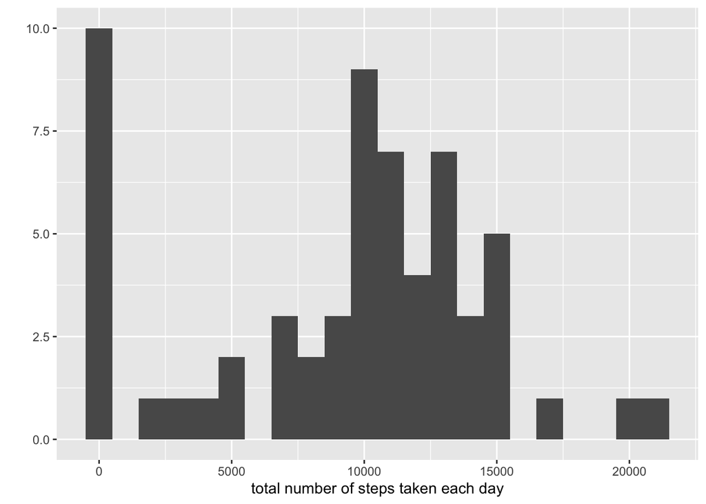

```r
DFsteps <- tapply(DF$steps, DF$date, FUN=sum, na.rm=TRUE)
library(ggplot2)
qplot(DFsteps, binwidth=1000, xlab="total number of steps taken each day")
```

3. Calculate and report the mean and median of the total number of steps taken per day

```r
stepsMean <-round(mean(DFsteps))
stepsMean
```

```
## [1] 9354
```

```r
stepsmedian <- round(median(DFsteps))
stepsmedian
```

```
## [1] 10395
```

## Question B: What is the average daily activity pattern?

1. Make a time series plot of the 5-minute interval (x-axis) and the average number of steps taken, averaged across all days (y-axis)

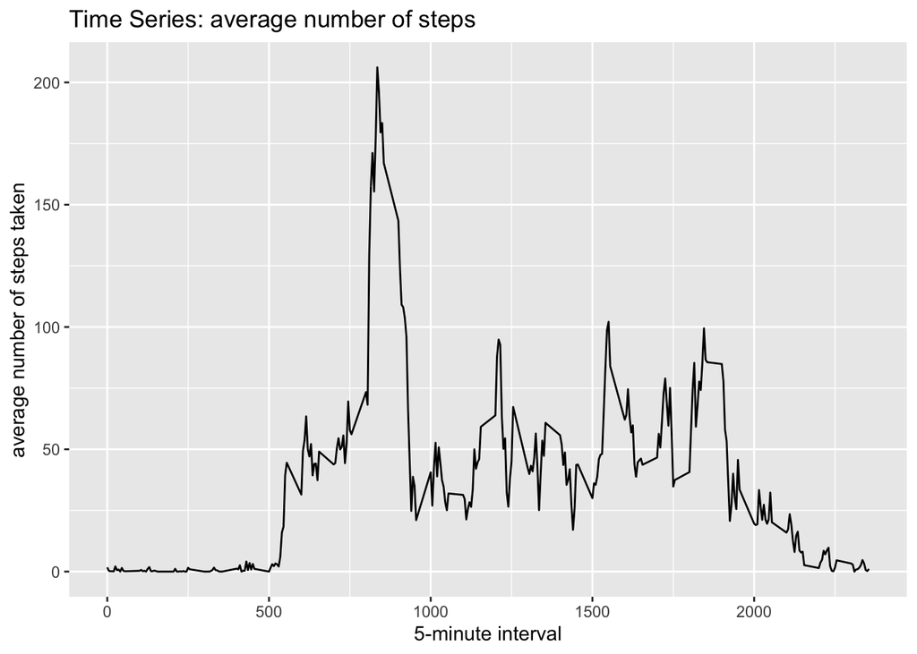

```r
averages <- aggregate(x=list(steps=DF$steps), by=list(interval=DF$interval),FUN=mean, na.rm=TRUE)
ggplot(data=averages, aes(x=interval, y=steps)) +
  geom_line() +
  ggtitle("Time Series: average number of steps") +
  xlab("5-minute interval") +
  ylab("average number of steps taken")
```

2. The 5-minute interval that, on average, contains the maximum number of steps

```r
averages[which.max(averages$steps),]
```

```
##     interval    steps
## 104      835 206.1698
```

The participant usually takes the most steps (206) between 8:35 and 8:40 AM.

## Question C: Inputing missing values

1. Calculate and report the total number of missing values in the dataset

```r
DF2 <- DF
DF2$CI <- "original"
l <- nrow(DF2)
length(which(is.na(DF2$steps)))
```

```
## [1] 2304
```

2 and 3. Strategy for filling in, and Create a new dataset that is equal to the original dataset but with the missing data filled in.

```r
for (i in 1:l) {
  if (is.na(DF2[i,1])) {
    DF2[i,1] <- averages[averages$interval == DF2[i,3],2]
    DF2[i,4] <- "completed"
  }
}

length(which(is.na(DF2$steps)))
```

```
## [1] 0
```

```r
length(which(DF2$CI=="completed"))
```

```
## [1] 2304
```

4. Historgram and Calculate and report the mean and median total number of steps taken per day

```r
DFsteps2 <- tapply(DF2$steps, DF2$date, FUN=sum, na.rm=TRUE )
stepsMean2 <- mean(DFsteps2)
stepsMedian2 <- median(DFsteps2)
c(stepsMean2,stepsMean)
```

```
## [1] 10766.19  9354.00
```

```r
c(stepsMedian2,stepsmedian)
```

```
## [1] 10766.19 10395.00
```

Mean increased to 10766, increased from 9354 earlier. The median of the distribution also increased from 10395 to 10766.

```r
library(gridExtra)
```

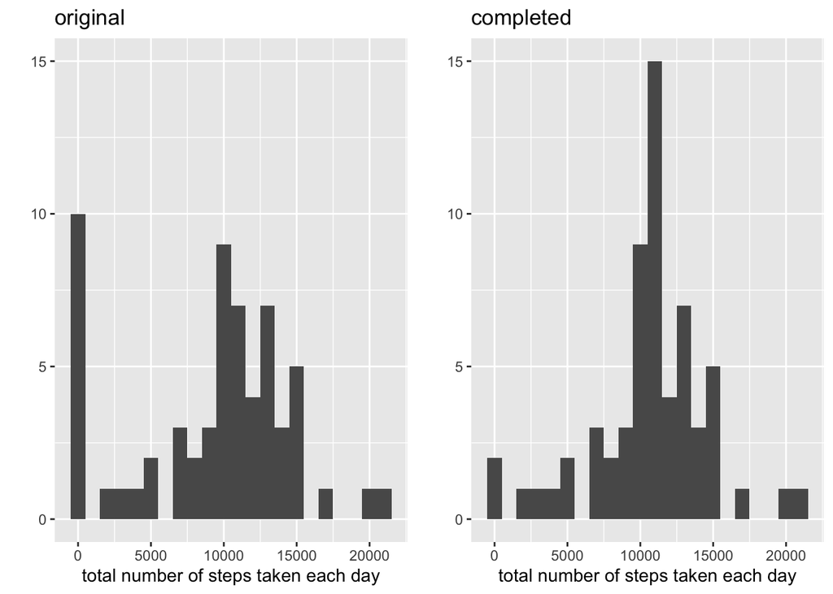

```r
require(gridExtra)
par(mfrow=c(1,2))
plot1 <- qplot(DFsteps,
               binwidth=1000,
               ylim=c(0,15),
               main="original",
               xlab="total number of steps taken each day")

plot2 <- qplot(DFsteps2,
               binwidth=1000,
               ylim=c(0,15),
               main="completed",
               xlab="total number of steps taken each day")

grid.arrange(plot1, plot2, ncol=2)
```

## Question D Are there differences in activity patterns between weekdays and weekends?

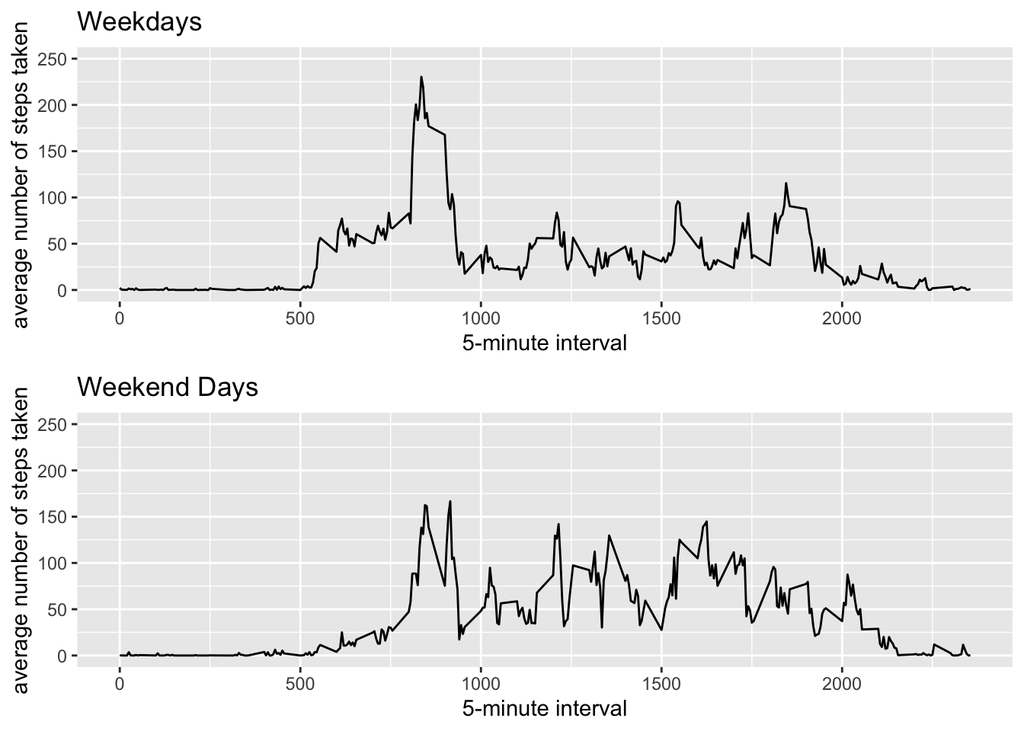

```r
library(ggplot2)
library(gridExtra)


DF2[,2] <- as.Date(DF2[,2])
DF2$WD <- weekdays(DF2[,2])
DF2$WDG <- "week"               # default = "week"

for (i in 1:l) {
  if (DF2[i,5] == "Saturday" | DF2[i,5] == "Sunday") {
    DF2[i,6] <- "weekend"
  }
}

DF2[,6] <- as.factor(DF2[,6])

DF2w <-subset(DF2,DF2[,6]=="week")
DF2we <-subset(DF2,DF2[,6]=="weekend")

averagesW <- aggregate(steps ~ interval, DF2w, FUN=mean)
averagesWe <- aggregate(steps ~ interval, DF2we, FUN=mean)

plot1 <- ggplot(data=averagesW, aes(x=interval, y=steps)) +
         geom_line() +
         ylim(0, 250) +
          ggtitle("Weekdays") +
         xlab("5-minute interval") +
         ylab("average number of steps taken")

plot2 <- ggplot(data=averagesWe, aes(x=interval, y=steps)) +
         geom_line() +
         ylim(0, 250) +
         ggtitle("Weekend Days") +
         xlab("5-minute interval") +
         ylab("average number of steps taken")

require(gridExtra)

grid.arrange(plot1, plot2, nrow=2)
```